# Chapter 6 – Mixed effect models – Exercise solutions and Code Boxes

David Warton

2025-06-06

## Exercise 6.1: Effects of water pollution on subtidal marine micro-invertebrates

*What factors are there? Fixed or random?*

*Modification* is a factor, taking levels “Pristine” and “Modified”

*Estuary* is a factor, taking seven levels. If these were sampled randomly, and we want to make inferences across all estuaries on the New South Wales coast, it oculd be treated as a random factor.

The 4-7 samples at each estuary are the replicates, so they shouldn’t be added to the model, variation in replicates will enter through the error term.

## code for Fig 6.1

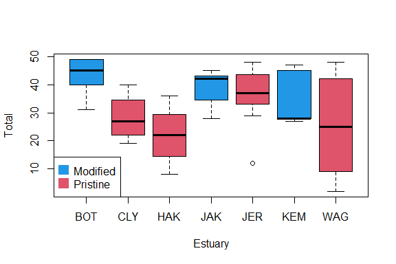

```r
library(ecostats)
data(estuaries)
plot(Total~Estuary,data=estuaries,col=c(4,2,2,4,2,4,2))
legend("bottomleft",legend=c("Modified","Pristine"),col=c(4,2),pch=15,pt.cex=2)
```

## Code Box 6.1: Fitting a linear mixed model to the estuary data of Exercise 6.1

```r
library(ecostats)
data(estuaries)
library(lme4)
ft_estu = lmer(Total~Mod+(1|Estuary),data=estuaries)
summary(ft_estu)
```

```
#> Linear mixed model fit by REML ['lmerMod']
#> Formula: Total ~ Mod + (1 | Estuary)
#>    Data: estuaries
#>
#> REML criterion at convergence: 314.4
#>
#> Scaled residuals:
#>     Min      1Q  Median      3Q     Max
#> -2.2393 -0.7569  0.1553  0.7372  1.8962
#>
#> Random effects:
#>  Groups   Name        Variance Std.Dev.
#>  Estuary  (Intercept)  10.68    3.268
#>  Residual             123.72   11.123
#> Number of obs: 42, groups:  Estuary, 7
#>
#> Fixed effects:
#>             Estimate Std. Error t value
#> (Intercept)   39.053      3.237  12.065
#> ModPristine  -11.243      4.287  -2.622
#>
#> Correlation of Fixed Effects:
#>             (Intr)
#> ModPristine -0.755
```

There is some evidence of an effect of `Mod`, since the estimated coefficient is more than double its standard error (so a 95% confidence interval would not cover zero). The effect appears to be a decrease in total abundance in pristine estuaries.

## Code Box 6.2: Residual plots from a mixed model for Exercise 6.1

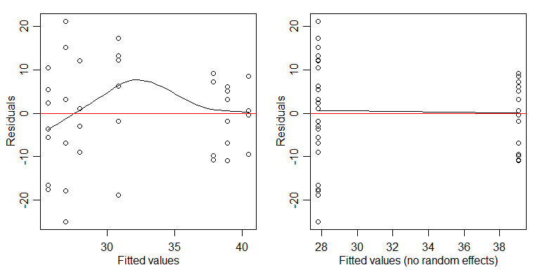

```r
par(mfrow=c(1,2),mar=c(3,3,1,1),mgp=c(1.75,0.75,0))
ft_estu = lmer(Total~Mod+(1|Estuary),data=estuaries)
scatter.smooth(residuals(ft_estu)~fitted(ft_estu),
    xlab="Fitted values",ylab="Residuals")
abline(h=0,col="red")
scatter.smooth(residuals(ft_estu)~predict(ft_estu,re.form=NA),
    xlab="Fitted values (no random effects)",ylab="Residuals")
abline(h=0,col="red")
```

## Code Box 6.3: Using `anova` to compare mixed effects models for the estuary data

```r
ft_estu = lmer(Total~Mod+(1|Estuary),data=estuaries,REML=F)
ft_estuInt = lmer(Total~(1|Estuary),data=estuaries,REML=F)
anova(ft_estuInt,ft_estu)
```

```
#> Data: estuaries
#> Models:
#> ft_estuInt: Total ~ (1 | Estuary)
#> ft_estu: Total ~ Mod + (1 | Estuary)
#>            npar    AIC    BIC  logLik -2*log(L)  Chisq Df Pr(>Chisq)
#> ft_estuInt    3 334.18 339.39 -164.09    328.18
#> ft_estu       4 330.14 337.09 -161.07    322.14 6.0396  1    0.01399 *
#> ---
#> Signif. codes:  0 '***' 0.001 '**' 0.01 '*' 0.05 '.' 0.1 ' ' 1
```

There is some evidence of an effect of modification.

## Code Box 6.4: Confidence intervals for parameters from a mixed effects model for the estuary data

```r
confint(ft_estu)
```

```
#> Computing profile confidence intervals ...
#>                  2.5 %    97.5 %
#> .sig01        0.000000  7.613337
#> .sigma        8.944066 14.084450
#> (Intercept)  32.815440 45.246159
#> ModPristine -19.461059 -2.994392
```

## Code Box 6.5: Prediction intervals for random effects terms in a mixed effects model

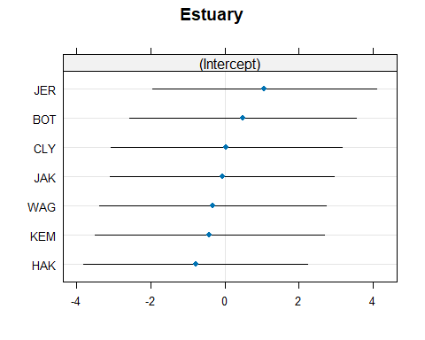

```r
rft=ranef(ft_estu,condVar=T)
library(lattice)
dotplot(rft)
```

## Exercise 6.2: Fitting random effects with different variances

```r
estuaries$isMod = as.numeric(estuaries$Mod=="Modified")
estuaries$isPri = as.numeric(estuaries$Mod!="Modified")
ft_estuDiff = lmer(Total~Mod+(0+isMod|Estuary)+(0+isPri|Estuary),data=estuaries,REML=F)
```

```
#> boundary (singular) fit: see help('isSingular')
```

```r
summary(ft_estuDiff)
```

```
#> Linear mixed model fit by maximum likelihood  ['lmerMod']
#> Formula: Total ~ Mod + (0 + isMod | Estuary) + (0 + isPri | Estuary)
#>    Data: estuaries
#>
#>       AIC       BIC    logLik -2*log(L)  df.resid
#>     331.7     340.4    -160.8     321.7        37
#>
#> Scaled residuals:
#>     Min      1Q  Median      3Q     Max
#> -2.2790 -0.7211  0.2024  0.6807  1.9407
#>
#> Random effects:
#>  Groups    Name  Variance Std.Dev.
#>  Estuary   isMod   0.00    0.000
#>  Estuary.1 isPri  11.39    3.375
#>  Residual        118.84   10.901
#> Number of obs: 42, groups:  Estuary, 7
#>
#> Fixed effects:
#>             Estimate Std. Error t value
#> (Intercept)   39.111      2.569   15.22
#> ModPristine  -11.303      3.806   -2.97
#>
#> Correlation of Fixed Effects:
#>             (Intr)
#> ModPristine -0.675
#> optimizer (nloptwrap) convergence code: 0 (OK)
#> boundary (singular) fit: see help('isSingular')
```

```r
BIC(ft_estu,ft_estuDiff)
```

```
#>             df      BIC
#> ft_estu      4 337.0880
#> ft_estuDiff  5 340.3501
```

BIC suggests that we didn’t need a different variance term for each level of `Mod`. (It also estimated the cross-estuary variance to be zero for modified estuaries, leading to a warning in the output.)

## Exercise 6.3: Bird exclusion and biological control

```r
data(aphidsBACI)
str(aphidsBACI)
```

```
#> 'data.frame':    16 obs. of  5 variables:
#>  $ Plot     : Factor w/ 8 levels "1","2","3","4",..: 1 2 3 4 5 6 7 8 1 2 ...
#>  $ Treatment: Factor w/ 2 levels "excluded","present": 2 2 2 2 1 1 1 1 2 2 ...
#>  $ Time     : Factor w/ 2 levels "X18.06.","X15.07.": 1 1 1 1 1 1 1 1 2 2 ...
#>  $ counts   : int  78 71 122 271 119 152 120 202 60 48 ...
#>  $ logcount : num  4.37 4.28 4.81 5.61 4.79 ...
```

OK so we are looking for a `Treatment:Time` interaction, but to account for repeated measures of each plot, we want a random effect for `Plot` in the model.

```r
ft_aphids=lmer(logcount~Treatment*Time+(1|Plot),data=aphidsBACI)
```

```
#> boundary (singular) fit: see help('isSingular')
```

```r
ft_aphidNull=lmer(logcount~Time+(1|Plot),data=aphidsBACI)
```

```
#> boundary (singular) fit: see help('isSingular')
```

```r
anova(ft_aphidNull,ft_aphids)
```

```
#> refitting model(s) with ML (instead of REML)
#> Data: aphidsBACI
#> Models:
#> ft_aphidNull: logcount ~ Time + (1 | Plot)
#> ft_aphids: logcount ~ Treatment * Time + (1 | Plot)
#>              npar    AIC    BIC   logLik -2*log(L)  Chisq Df Pr(>Chisq)
#> ft_aphidNull    4 28.204 31.294 -10.1020    20.204
#> ft_aphids       6 26.974 31.609  -7.4868    14.973 5.2304  2    0.07315 .
#> ---
#> Signif. codes:  0 '***' 0.001 '**' 0.01 '*' 0.05 '.' 0.1 ' ' 1
```

Which gives us marginal evidence of an effect of bird exclusion of aphid counts.

Compare this to what we got when adding `Plot` as a fixed effect:

```r
lm_aphids=lm(logcount~Plot+Treatment*Time,data=aphidsBACI)
anova(lm_aphids)
```

```
#> Analysis of Variance Table
#>
#> Response: logcount
#>                Df Sum Sq Mean Sq F value   Pr(>F)
#> Plot            7 0.8986  0.1284  0.4603 0.833357
#> Time            1 5.4675  5.4675 19.6038 0.004434 **
#> Treatment:Time  1 0.7397  0.7397  2.6522 0.154527
#> Residuals       6 1.6734  0.2789
#> ---
#> Signif. codes:  0 '***' 0.001 '**' 0.01 '*' 0.05 '.' 0.1 ' ' 1
```

```r
summary(lm_aphids)
```

```
#>
#> Call:
#> lm(formula = logcount ~ Plot + Treatment * Time, data = aphidsBACI)
#>
#> Residuals:
#>     Min      1Q  Median      3Q     Max
#> -0.5527 -0.1929  0.0000  0.1929  0.5527
#>
#> Coefficients: (1 not defined because of singularities)
#>                              Estimate Std. Error t value Pr(>|t|)
#> (Intercept)                    4.6097     0.4175  11.041 3.28e-05 ***
#> Plot2                         -0.1559     0.5281  -0.295  0.77776
#> Plot3                          0.3378     0.5281   0.640  0.54600
#> Plot4                          0.4433     0.5281   0.839  0.43336
#> Plot5                          0.2127     0.5904   0.360  0.73105
#> Plot6                          0.3530     0.5904   0.598  0.57179
#> Plot7                          0.6593     0.5904   1.117  0.30685
#> Plot8                          0.2631     0.5904   0.446  0.67154
#> Treatmentpresent                   NA         NA      NA       NA
#> TimeX15.07.                   -1.5992     0.3734  -4.282  0.00519 **
#> Treatmentpresent:TimeX15.07.   0.8601     0.5281   1.629  0.15453
#> ---
#> Signif. codes:  0 '***' 0.001 '**' 0.01 '*' 0.05 '.' 0.1 ' ' 1
#>
#> Residual standard error: 0.5281 on 6 degrees of freedom
#> Multiple R-squared:  0.8094, Adjusted R-squared:  0.5235
#> F-statistic: 2.831 on 9 and 6 DF,  p-value: 0.1091
```

```r
summary(ft_aphids)
```

```
#> Linear mixed model fit by REML ['lmerMod']
#> Formula: logcount ~ Treatment * Time + (1 | Plot)
#>    Data: aphidsBACI
#>
#> REML criterion at convergence: 20.2
#>
#> Scaled residuals:
#>     Min      1Q  Median      3Q     Max
#> -1.2314 -0.4755 -0.2367  0.3187  1.8824
#>
#> Random effects:
#>  Groups   Name        Variance Std.Dev.
#>  Plot     (Intercept) 0.000    0.0000
#>  Residual             0.199    0.4461
#> Number of obs: 16, groups:  Plot, 8
#>
#> Fixed effects:
#>                              Estimate Std. Error t value
#> (Intercept)                    4.9817     0.2231  22.334
#> Treatmentpresent              -0.2157     0.3155  -0.684
#> TimeX15.07.                   -1.5992     0.3155  -5.069
#> Treatmentpresent:TimeX15.07.   0.8601     0.4461   1.928
#>
#> Correlation of Fixed Effects:
#>             (Intr) Trtmnt TX15.0
#> Trtmntprsnt -0.707
#> TimeX15.07. -0.707  0.500
#> Tr:TX15.07.  0.500 -0.707 -0.707
#> optimizer (nloptwrap) convergence code: 0 (OK)
#> boundary (singular) fit: see help('isSingular')
```

We get the same point estimate for the `Treatment:Time` effect, but the standard error is slightly smaller in the random effects model.

## Exercise 6.4: Estuary data in different zones

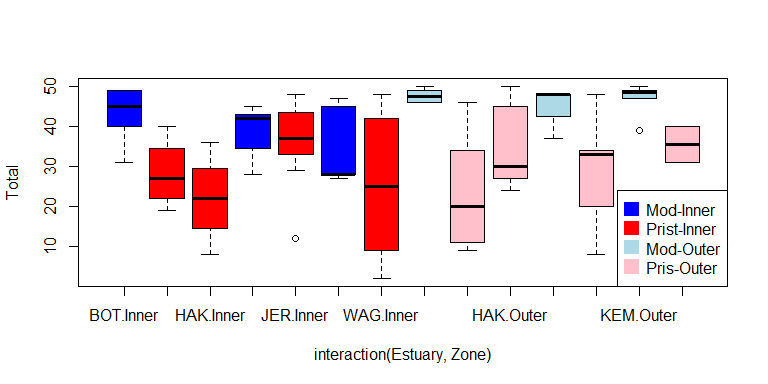

```r
data(estuaryZone)
cols=c("blue","red","lightblue","pink")
plot(Total~interaction(Estuary,Zone),data=estuaryZone,col=cols[c(1,2,2,1,2,1,2,3,4,4,3,4,3,4)])
legend("bottomright",legend=c("Mod-Inner","Prist-Inner","Mod-Outer","Pris-Outer"),col=cols,pch=15,pt.cex=2)
```

It looks like there is an effect of Modification, not sure if there is an interaction (the effect seems more striking in Outer than Inner zones)

```r
par(mfrow=c(1,2),mar=c(3,3,1,1),mgp=c(1.75,0.75,0))
library(lme4)
lme_MZ = lmer(Total~Zone*Mod + (Zone|Estuary), data=estuaryZone )
```

```
#> boundary (singular) fit: see help('isSingular')
```

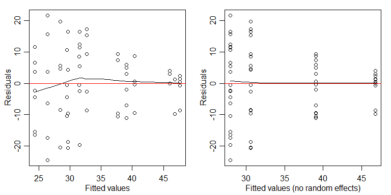

```r
scatter.smooth(residuals(lme_MZ)~fitted(lme_MZ),
    xlab="Fitted values",ylab="Residuals")
abline(h=0,col="red")
scatter.smooth(residuals(lme_MZ)~predict(lme_MZ,re.form=NA),
    xlab="Fitted values (no random effects)",ylab="Residuals")
abline(h=0,col="red")
```

```r
lme_MplusZ = lmer(Total~Zone+Mod + (Zone|Estuary), data=estuaryZone )
```

```
#> boundary (singular) fit: see help('isSingular')
```

```r
anova(lme_MplusZ,lme_MZ)
```

```
#> refitting model(s) with ML (instead of REML)
#> Data: estuaryZone
#> Models:
#> lme_MplusZ: Total ~ Zone + Mod + (Zone | Estuary)
#> lme_MZ: Total ~ Zone * Mod + (Zone | Estuary)
#>            npar    AIC    BIC  logLik -2*log(L)  Chisq Df Pr(>Chisq)
#> lme_MplusZ    7 595.91 612.31 -290.95    581.91
#> lme_MZ        8 597.14 615.89 -290.57    581.14 0.7618  1     0.3828
```

No evidence of an interaction between Zone and Modification. Testing for a `Mod` main effect:

```r
lme_Z = lmer(Total~Zone + (Zone|Estuary), data=estuaryZone )
anova(lme_Z,lme_MplusZ)
```

```
#> refitting model(s) with ML (instead of REML)
#> Data: estuaryZone
#> Models:
#> lme_Z: Total ~ Zone + (Zone | Estuary)
#> lme_MplusZ: Total ~ Zone + Mod + (Zone | Estuary)
#>            npar    AIC    BIC  logLik -2*log(L)  Chisq Df Pr(>Chisq)
#> lme_Z         6 608.43 622.50 -298.22    596.43
#> lme_MplusZ    7 595.91 612.31 -290.95    581.91 14.529  1   0.000138 ***
#> ---
#> Signif. codes:  0 '***' 0.001 '**' 0.01 '*' 0.05 '.' 0.1 ' ' 1
```

There is strong evidence that total abundance is different between Modified and Pristine estuaries. The boxplot suggests abundance is higher in Modified estuaries, and looking at the data, this appears to be mostly due to high counts of `Balanus.variegatus`, especially in outer modified zones.

## Code Box 6.6: Using the parametric bootstrap to compute the standard error of the `Mod` fixed effect in Exercise 6.1.

```r
nBoot=500
bStat=rep(NA,nBoot)
ft_estu = lmer(Total~Mod+(1|Estuary),data=estuaries)
for(iBoot in 1:nBoot)
{
   estuaries$TotalSim=unlist(simulate(ft_estu))
   ft_i = lmer(TotalSim~Mod+(1|Estuary),data=estuaries)
   bStat[iBoot] = fixef(ft_i)[2]
}
sd(bStat) #standard error of Mod effect
```

```
#> [1] 4.260999
```

And if we compare this to the standard error from `summary`:

```r
summary(ft_estu)
```

```
#> Linear mixed model fit by REML ['lmerMod']
#> Formula: Total ~ Mod + (1 | Estuary)
#>    Data: estuaries
#>
#> REML criterion at convergence: 314.4
#>
#> Scaled residuals:
#>     Min      1Q  Median      3Q     Max
#> -2.2393 -0.7569  0.1553  0.7372  1.8962
#>
#> Random effects:
#>  Groups   Name        Variance Std.Dev.
#>  Estuary  (Intercept)  10.68    3.268
#>  Residual             123.72   11.123
#> Number of obs: 42, groups:  Estuary, 7
#>
#> Fixed effects:
#>             Estimate Std. Error t value
#> (Intercept)   39.053      3.237  12.065
#> ModPristine  -11.243      4.287  -2.622
#>
#> Correlation of Fixed Effects:
#>             (Intr)
#> ModPristine -0.755
```

we see the estimated standard error is 4.287348, which is pretty close to the value we got by simulation.

## Code Box 6.7: A parametric bootstrap to test for an effect of Estuary in Exercise 6.1.

```r
ft_noestu = lm(Total~Mod,data=estuaries)
library(ecostats)
anovaPB(ft_noestu,ft_estu,n.sim=99, ncpus=1)
```

```
#> Error in x$terms : $ operator not defined for this S4 class
#> Warning in Ops.factor(1, Estuary): '|' not meaningful for factors
#>
#> Analysis of Deviance Table
#>
#> ft_noestu: Total ~ Mod
#> ft_estu: Total ~ Mod + (1 | Estuary)
#>           df deviance   LRT Pr(>LRT)
#> ft_noestu  3    322.2
#> ft_estu    4    314.4 7.832     0.26
#>
#> P-value calculated by simulating 99 samples from ft_noestu.
```

So we have no evidence of an `Estuary` effect. (The `ncpus` argument was specified here to avoid parallel processing. This was only done to avoid errors when compiling this file on computers set to use just one cpu for `R`.)

## Exercise 6.6: Accurate inferences about the estuary data

*Use the parametric bootstrap to get a formal test for a `zone:mod` interaction.*

We can just run the old analysis and change from `anova` to `anovaPB`:

```r
lme_MZ = lmer(Total~Zone*Mod + (Zone|Estuary), data=estuaryZone, REML=FALSE )
lme_MplusZ = lmer(Total~Zone+Mod + (Zone|Estuary), data=estuaryZone, REML=FALSE )
anovaPB(lme_MplusZ,lme_MZ,n.sim=99,ncpus=1)
```

```
#> Warning in Ops.factor(Zone, Estuary): '|' not meaningful for factors
#> Warning in checkConv(attr(opt, "derivs"), opt$par, ctrl = control$checkConv, :
#> Model failed to converge with max|grad| = 0.00848004 (tol = 0.002, component 1)
#>
#> Data: estuaryZone
#> Models:
#> objectNull: Total ~ Zone + Mod + (Zone | Estuary)
#> object: Total ~ Zone * Mod + (Zone | Estuary)
#>            npar   AIC   BIC logLik -2*log(L) Chisq Pr(>Chisq)
#> objectNull    7 595.9 612.3 -291.0     581.9
#> object        8 597.1 615.9 -290.6     581.1 0.762       0.43
#>
#> P-value calculated by simulating 99 samples from objectNull.
```

There is no evidence of an interaction.

(Ignore the warnings in the output – this is random stuff that was thrown up in bootstrap resamples that didn’t get a good fit.)

*How do results compare to those from when you were using the `anova` function?*

Results are similar to what we saw before. The only thing that is different is the $P$-value, but it is very similar (suggesting there was no need for a parametric bootstrap here!).

*This would all have been so much easier if there wasn’t a random effect in the model… do we really need `Estuary` in there?*

```r
lme_MZ = lmer(Total~Zone*Mod + (Zone|Estuary), data=estuaryZone, REML=FALSE )
lme_MZnoest = lm(Total~Zone+Mod, data=estuaryZone)
anovaPB(lme_MZnoest,lme_MZ,n.sim=99,ncpus=1)
```

```
#> Error in x$terms : $ operator not defined for this S4 class
#> Warning in Ops.factor(Zone, Estuary): '|' not meaningful for factors
#>
#> Analysis of Deviance Table
#>
#> lme_MZnoest: Total ~ Zone + Mod
#> lme_MZ: Total ~ Zone * Mod + (Zone | Estuary)
#>             df deviance   LRT Pr(>LRT)
#> lme_MZnoest  4    582.8
#> lme_MZ       8    581.1 1.684     0.29
#>
#> P-value calculated by simulating 99 samples from lme_MZnoest.
```

We have no evidence of an `Estuary` effect either!